# MAT150 - Summer 2023

Phd. Anabela Romina Turlione

Digipen, Bilbao

**Content**

- Functions
  - Algebraic representations
  - Graphic representations
  - Simmetry
  - Increasing and Decrasing functions
- Basic Functions
- Basic operations
- Combination of functions
- More Functions

# Functions

A function is a **rule** that assigns to each element $x$ in a set $D$ exactly one element, called $y$, in a set $E$. $f : x \in D \rightarrow y \in E$.

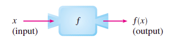

- Input: independent variable(s): $x$
- Output: dependent variable: $y$
- $D:$ domain
- $E:$ range (the set of all possible values of $f(x)$ as $x$ varies throughout the domain)
- Usually $D\in \Re$ and $E\in \Re$

## Algebraic representations

**Example 1:**

A straight line

## Graphic representations

**Arrow diagram**

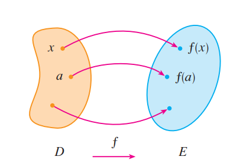

**Graph**

set of ordered pairs $\{(x,f(x))|x\in D\}$

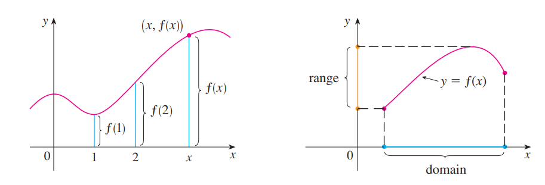

The relation between a graph and its algebraic expression must be completely **univocal**, that is, we need to get the same information from both without ambiguities.

**THE VERTICAL LINE TEST**

A curve in the xy-plane is the graph of a function if and only if no vertical line intersects the curve more than once.

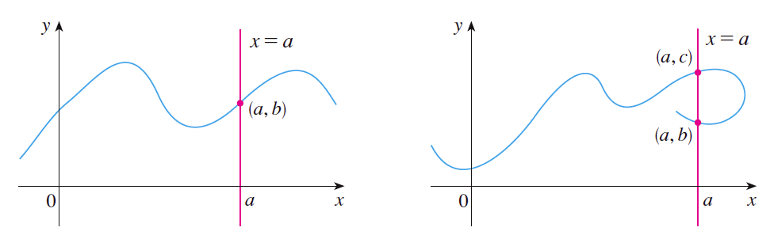

**Example 2**

What are the domain and range of $f$?

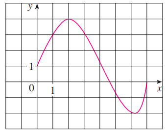

**Solution:**

Domain: $\{x|0 \le x \le7 \} = [0,7]$

Range: $\{y|-2 \le y \le4 \} = [-2,4]$

## Simmetry

If a function satisfies $f(-x)=f(x)$ for every number in its domain, then is called an **even** function.

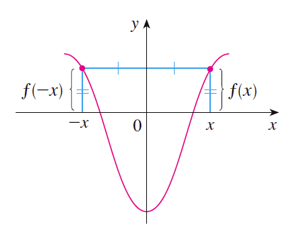

For instance $f(x)=x^2$

If $f$ satisfies $f(-x)=-f(x)$ for every number in its domain, then is called an **odd** function.

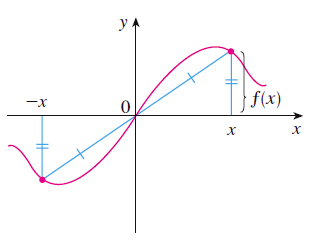

For instance $f(x)=x^3$

## Increasing and Decrasing functions

- A function is called **increasing** on an interval $I$ if $f(x_1)<f(x_2)$ whenever $x_1<x_2$ in $I$.
- It is called **decreasing** on if $f(x_1)>f(x_2)$ whenever $x_1<x_2$ in $I$.

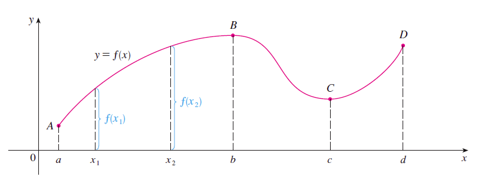

# Basic Functions

**Basic explicit functions:** $y=f(x)$

- Polinomials $\Leftrightarrow$ Irrational
- Exponentials $\Leftrightarrow$ Logaritmic
- Trigonometrical $\Leftrightarrow$ Transcendental

**Implicit functions:** Circles and parabolas (quadratic-conic sections)

## Polynomials

- In general, polynomials are represented as: $P_n(x) = a_0 +a_1x+a_2x^2+a_3^3+\cdots + a_nx^n$
- Where, $n>0$, is the order of the polynomial and $a_0,a_1,...,a_n$ are constants called the coefficients of the polynomial.
- The domain of any polynomial is $(-\infty,\infty)$. If the leading coefficient $a_n\ne0$, then the degree of the polynomial is $n$.

Let's plot some polynomials...

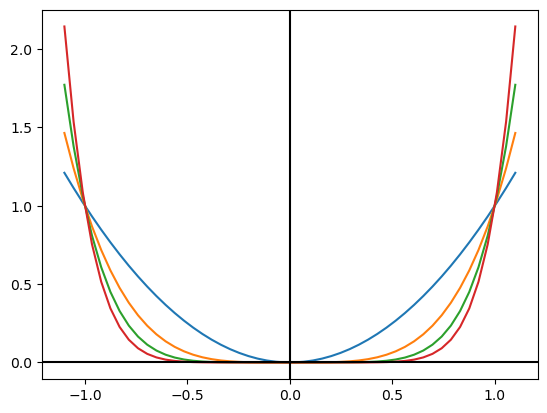

```python
import matplotlib.pyplot as plt
import numpy as np

x=np.linspace(-1.1,1.1)

plt.plot(x,x**2)
plt.plot(x,x**4)
plt.plot(x,x**6)
plt.plot(x,x**8)
plt.axhline(y = 0, color = 'k', linestyle = '-')
plt.axvline(x = 0, color = 'k', linestyle = '-')
```

As $n$ increases, the graph of $y=x^n$ becomes flatter near 0 and steeper when $|x|\geq$1.

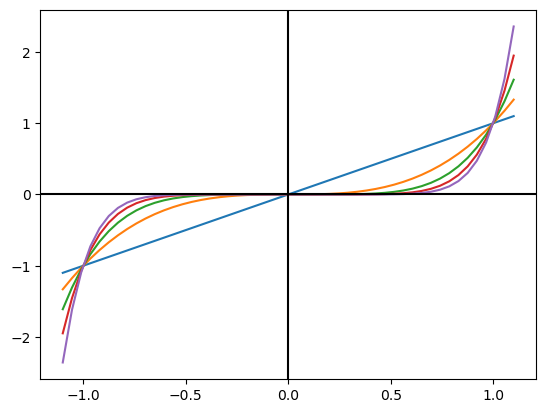

```python
plt.plot(x,x)
plt.plot(x,x**3)
plt.plot(x,x**5)
plt.plot(x,x**7)
plt.plot(x,x**9)
plt.axhline(y = 0, color = 'k', linestyle = '-')
plt.axvline(x = 0, color = 'k', linestyle = '-')
```

### Straight lines: $n=1$

- Explicit representation: $y=P_1(x)=a_1x+a_0$
- They are defined through 2 points, in general the intersection with the axes.

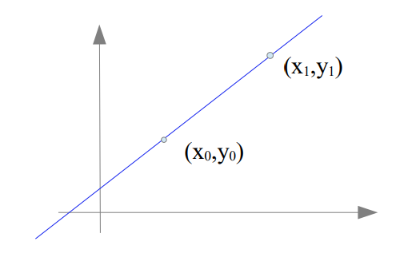

- Alternatively, straight lines are given through a point $(x_0,y_0)$ and its slope

\begin{equation} m = \frac{\Delta y}{\Delta x}=\frac{y_1-y_0}{x_1-x_0}, \end{equation}

where the symbol $\Delta$ means "variation, change"

- Alternative: $y-y_0=m(x-x_0)$

**Example 3**

Express the line through the points $(-1,3)$ and $(5,2)$ following the expression $y-y_0=m(x-x_0)$ and sketch it. Indicate the **intersections** with $x$ and $y$ axis.

### Parabolas: $n=2$

\begin{equation} y=P_2(x)=a_0+a_1x+a_2x^2 \end{equation}

**Example 4**

Find the intersections with the axis of the parabola $y=x^2−2 x−3$ . With these data, can you easily sketch it?

**Vertex**

The **vertex** of a parabola is the extreme of the curve, and identifying it will help up to sketch the parabola intuitively.

**Example 5**

Sketch and find the vertex of:

1. $y=x^2$
2. $y = (x-1)^2$
3. $y=-x^2$

What is produced by these operations from geometrical point of view?

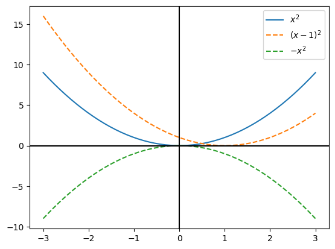

```python
import matplotlib.pyplot as plt
import numpy as np

x=np.linspace(-3,3)

def y(x):
    return x**2

plt.plot(x,y(x))
plt.plot(x,y(x-1),'--')
plt.plot(x,-y(x),'--')
plt.axhline(y = 0, color = 'k', linestyle = '-')
plt.axvline(x = 0, color = 'k', linestyle = '-')
plt.legend(['$x^2$','$(x-1)^2$','$-x^2$'])
```

## Basic operations: New functions from old functions

**Vertical and horizontal shifts**

- $f (x−a)$ : translation to the right (delay)
- $f (x+a)$ : translation to the left
- $y+b= f ( x)$ : translation upward
- $y−b= f ( x)$ : translation downward

**Vertical and horizontal stretching and reflecting**

Suppose $c>1$

- $y=cf(x)$ : stretch the graph vertically by a factor of c.
- $y=(1/c)f(x)$ : compress the graph vertically by a factor of c.
- $y=f(cx)$ : compress the graph horizontally by a factor of c.
- $y=f(x/c)$ : stretch the graph horizontally by a factor of c.
- $f (−x)$ : reflection about the y-axis.
- − $f (x)$ : reflection about x-axis
- The inverse: $f^ {-1}(x)$ reflection about $y=x$.

Let's plot some transformations...

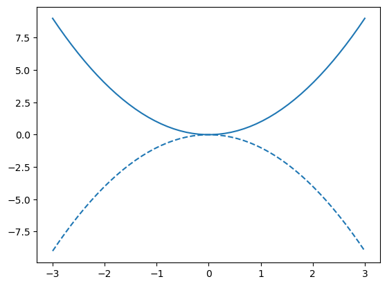

```python
x=np.linspace(-3,3)

plt.plot(x,y(x))
plt.plot(x,-y(x),'--',color='tab:blue')
```

**Example 6**

Find the vertex of the following parabolas **completing the square.**

1. $y=x^2-2x$
2. $y = x^2+3x+1$
3. $y = 2x^2+6x-1$
4. $y -6x+x^2=0$

**Solutions**

1. $y=\big(x-1\big)^2-1\Rightarrow V=(1,-1)$
2. $y=\big(x+3/2\big)^2-5/4\Rightarrow V=(-3/2,-5/4)$
3. $y=2\bigg[\big(x+3/2\big)^2-11/4\bigg]\Rightarrow V=(-3/2,-11/2)$
4. $y=-\big(x-3\big)^2+9\Rightarrow V=(3,9)$

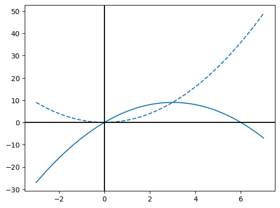

```python
x=np.linspace(-3,7)

plt.plot(x,y(x),'--')
plt.plot(x,-y(x-3)+9,color='tab:blue')
plt.axhline(y = 0, color = 'k', linestyle = '-')
plt.axvline(x = 0, color = 'k', linestyle = '-')
```

## The inverse of a function

The inverse of a function is the operation that does just the opposite of the original one. In other words, the inverse **undoes** what the function have done before.

**Definition**

Let $f$ be a one-to-one function with domain $A$ and range $B$. Then its **inverse function** has domain $B$ and range $A$ and is defined by

\begin{equation} f^{-1}=x \Leftrightarrow f(x)=y \end{equation}

for any $y$ in $B$.

Then ...

- domain of $f^{-1}$ = range of $f$
- range of $f^{-1}$ = domain of $f$

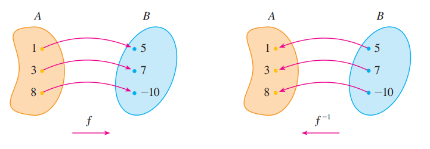

**Definition**

A function is called a one-to-one function if it never takes on the same value twice; that is,

\begin{equation} f(x_1)\ne f(x_2),~whenever~x_1\ne x_2 \end{equation}

**Horizontal line test**

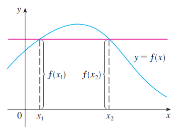

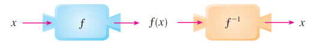

- $f^{-1}\big(f(x)\big)=x$ for every $x\in A$ (domain of $f$)
- $f\big(f^{-1}(x)\big)=x$ for every $x\in B$ (range of $f$)

**How to find the inverse of a function $f$**

1. Write $y=f(x)$.
2. Solve this equation for $x$ in terms of $y$.
3. interchage $x$ and $y$.

**Example 7**

Find the inverse of $y=2x+3$. Sketch both.

**Solution**

\begin{equation} y=\frac{x-3}{2} \end{equation}

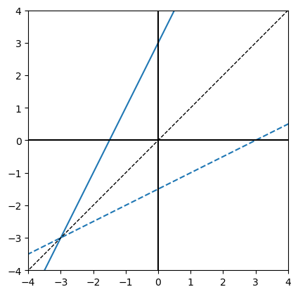

```python
x=np.linspace(-5,5)

plt.plot(x,2*x+3)
plt.plot(x,(x-3)/2,'--',color='tab:blue')
plt.plot(x,x,'--',color='k', linewidth=1)
plt.axhline(y = 0, color = 'k', linestyle = '-')
plt.axvline(x = 0, color = 'k', linestyle = '-')
# plt.axhline(y = 3, color = 'r', linestyle = '--')
# plt.axvline(x = -3/2, color = 'r', linestyle = '--')
plt.xlim([-4,4])
plt.ylim([-4,4])
ax = plt.gca()
ax.set_aspect('equal')
```

The graph of $f^{-1}$ is obtained by reflecting the graph of $f$ about the line $y=x$.

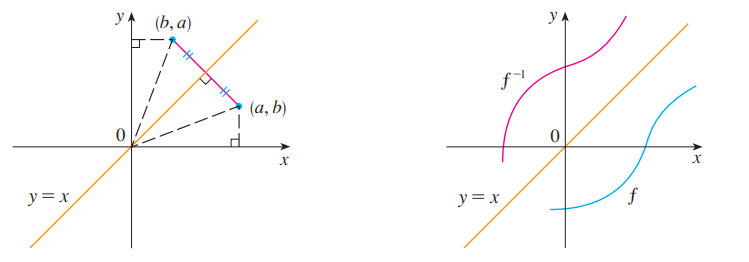

**Example 8**

Find the **inverse** of the following functions analytically (first, we solve x in the function of y and after that, we exchange x and y).

a. $y=3 x−1$

b. $y=3 x^5$

c. $y=\frac{3x-1}{2x+3}$

d. $y=x^2$

**Solution**

a. $y=(x+1)/3$

b. $y=(x/3)^{1/5}$

c. $y=(3x+1)/(3-2x)$

d. $y=\pm \sqrt{x}$

Notice that, the inverse of $y=x^2$ cannot be expressed in a singular explicit function. It has two definition (o parts), $y=\sqrt{x}$ and $y=-\sqrt{x}$.

If we would like to refer to a horizontal parabola with a unique expression we should use its **Implicit form**: $y^2=x$ . Note that x is still the input, and y the output.

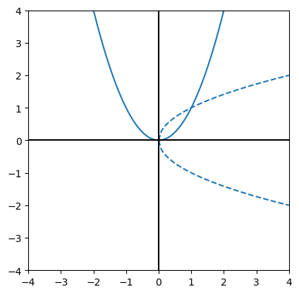

```python
x=np.linspace(-2,2)
x2=np.linspace(0,4)

plt.plot(x,x**2)
plt.plot(x2,-np.sqrt(x2),'--',color='tab:blue')
plt.plot(x2,np.sqrt(x2),'--',color='tab:blue')

plt.axhline(y = 0, color = 'k', linestyle = '-')
plt.axvline(x = 0, color = 'k', linestyle = '-')
# plt.axhline(y = 3, color = 'r', linestyle = '--')
# plt.axvline(x = -3/2, color = 'r', linestyle = '--')
plt.xlim([-4,4])
plt.ylim([-4,4])
ax = plt.gca()
ax.set_aspect('equal')
```

## Combination of functions

Given $f(x)$ and $g(x)$ with domains $A$ and $B$, respectively:

- $(f+g)(x)=f(x)+g(x)$, domain: $A\cap B$
- $(f-g)(x)=f(x)-g(x)$, domain: $A\cap B$
- $(fg)(x)=f(x)g(x)$, domain: $A\cap B$
- $(f/g)(x)=f(x)/g(x)$, domain: $\{x\in A\cap B|g(x)\ne0\}$

# More Functions

## Exponential Functions

$y(x)=a^x$, the variable $x$ is the exponent, $a>0$ and $x \in \Re$.

```python
x=np.linspace(-1.5,1.0)

def exp_func(a,x):
    return a**x
def plot_exps():
    plt.plot(x,exp_func(0.5,x))
    plt.plot(x,exp_func(0.25,x))
    plt.plot(x,exp_func(10,x))
    plt.plot(x,exp_func(4,x))
    plt.plot(x,exp_func(2,x))
    # plt.plot(x,exp_func(1.5,x))
    plt.plot(x,exp_func(1,x),'--')
    plt.xlim([-1,1])
    plt.ylim([-0.2,3])
    plt.axhline(y = 0, color = 'k', linestyle = '-')
    plt.axvline(x = 0, color = 'k', linestyle = '-')

    plt.text(-0.6, 2.5, '$a=1/4$')
    plt.text(-0.6, 1.6, '$a=1/2$')
    plt.text(-0.6, 1.05, '$a=1$')
    plt.text(0.45, 2.5, '$a=10$')
    plt.text(0.45, 1.7, '$a=4$')
    plt.text(0.45, 1.25, '$a=2$')
```

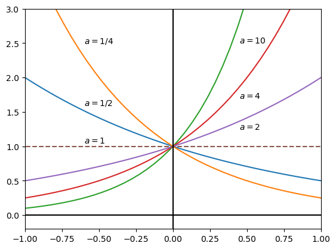

```python
plot_exps()
```

Properties:

**Laws of exponents**

- $a^{x+y}=a^xa^y$
- $a^{x-y}=a^x/a^y$
- $(a^x)^y=a^{xy}$
- $(ab)^x=a^xb^x$

Proof: Appendix G from Stewart - Calculus - Early Transcendentals (Thomson, 2008).

**Example 9**

Modeling growing populations:

- Population of bacteria in a homogeneous nutrient medium.
- The population doubles every hour.
- $P(0)=1000$

\begin{eqnarray} P(1)=2P(0)&=&2\times 1000\\ P(2)=2P(1)&=&2^2\times 1000\\ P(3)=2P(2)&=&2^3\times 1000\\ \end{eqnarray}

In general...

\begin{equation} P(t)=1000\times2^t \end{equation}

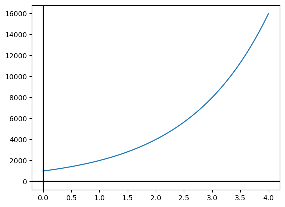

```python
t=np.linspace(0,4)

def P(t):
    return 1000*2**t

plt.plot(t,P(t))
plt.axhline(y = 0, color = 'k', linestyle = '-')
plt.axvline(x = 0, color = 'k', linestyle = '-')
```

**What about the human population?**

```python
import pandas as pd
year=range(1900,2000,10)
population=[1650,1750,1860,2070,2300,2560,3040,3710,4450,5280] #millions

human_population=pd.DataFrame({'year':year, 'Population':population})
human_population
```

|  | year | Population |
| --- | --- | --- |
| 0 | 1900 | 1650 |
| 1 | 1910 | 1750 |
| 2 | 1920 | 1860 |
| 3 | 1930 | 2070 |
| 4 | 1940 | 2300 |
| 5 | 1950 | 2560 |
| 6 | 1960 | 3040 |
| 7 | 1970 | 3710 |
| 8 | 1980 | 4450 |
| 9 | 1990 | 5280 |

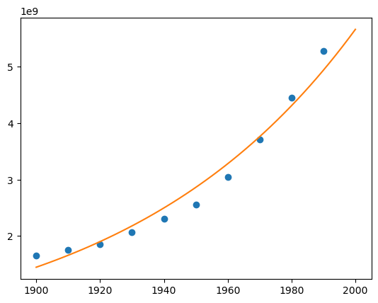

```python
time=np.linspace(1900,2000)
plt.plot(human_population['year'],human_population['Population']*10**6,'o')
plt.plot(time,0.008079266*(1.013731)**time)
```

**The number e**

- The most well know exponential is the natural exponential: $y=e^x$ with $e=euler~number$.
- The natural exponential function crosses the y-axis with a slope of 1.
- The inverse are natural logarithmic functions $\Rightarrow e^{ln(y)}=y$

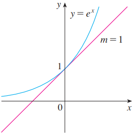

# Logarithmic Function

**Definition**

\begin{equation} log_ax=y \Leftrightarrow a^y=x, ~ if a>0~and~a\ne1 \end{equation}

- $log_a(a^x)=x$ for every $x \in \Re$
- $a^{log_ax}=x$ for every $x>0$
- It is the inverse function to exponentiation.
- The logarithm of a number x to the base a, $\log_a(x)$, is the exponent to which b must be raised, to produce x.
- The logarithm of base $e$ is the $natural~logarithm$, $\ln(x)$.
- $x>0,~a>0$

Properties:

- $\log_{a}\big(xy\big)=\log_bx+\log_by$
- $\log_a\big(\frac{x}{y}\big)=\log_bx-\log_by$
- $\log_a\big(x^p)=p~\log_ax$
- $\log_a\sqrt[p] x=\frac{\log_ax}{p}$

Change of base $b\rightarrow k$:

\begin{equation} \log_kx=\frac{\log_bx}{\log_bk} \end{equation}

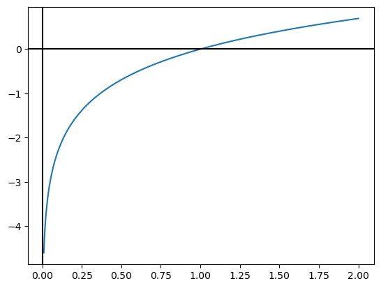

```python
t=np.linspace(0.01,2,1000)

plt.plot(t,np.log(t))
plt.axhline(y = 0, color = 'k', linestyle = '-')
plt.axvline(x = 0, color = 'k', linestyle = '-')
```

Domain: $\{x|0< x\}= (0,+\infty)$

Range: $\{y|~ y \in \Re\}$

**Exponential & Logarithmic**

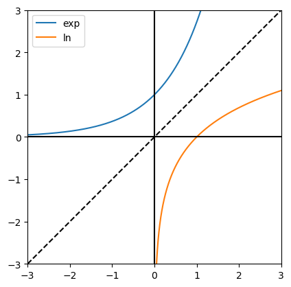

```python
t1=np.linspace(-3,2,1000)
t2=np.linspace(0.01,3,1000)
t3=np.linspace(-3,3,1000)

plt.plot(t1,np.exp(t1))
plt.plot(t2,np.log(t2))
plt.plot(t3,t3,'--' ,color='k')
plt.axhline(y = 0, color = 'k', linestyle = '-')
plt.axvline(x = 0, color = 'k', linestyle = '-')
plt.legend(['exp','ln'])
plt.xlim([-3,3])
plt.ylim([-3,3])
ax = plt.gca()
ax.set_aspect('equal')
```

**Example 10**

Find the **inverse** of $y=2⋅e^{3x}$

**Solution** $y=(1/3)\ln(x/2)$

**Example 11**

Sketch the following exponentials. Indicate their domain and range

a. $y=e^{x+1}-5$

b. $y=e^{-x+1}+2$

c. Repeat the same with their inverse

**Solution**

- Inverse of a: $y=\ln(x+5)-1$
- Inverse of a: $y=1-\ln(x-2)$

How would you check it?

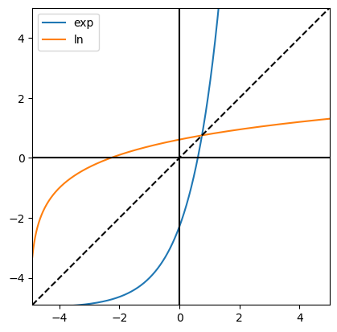

```python
x=np.linspace(-4.9,5,1000)

plt.plot(x,np.exp(x+1)-5)
plt.plot(x,np.log(x+5)-1)
plt.axhline(y = 0, color = 'k', linestyle = '-')
plt.axvline(x = 0, color = 'k', linestyle = '-')
plt.legend(['exp','ln'])

plt.plot(x,x,'--' ,color='k')

plt.xlim([-4.9,5])
plt.ylim([-4.9,5])
ax = plt.gca()
ax.set_aspect('equal')
```

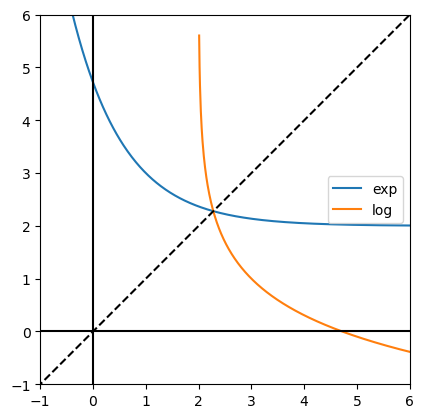

```python
x=np.linspace(-3,10,1000)
x1=np.linspace(2.01,10,1000)

plt.plot(x,np.exp(-x+1)+2)
plt.plot(x1,-np.log(x1-2)+1)
plt.axhline(y = 0, color = 'k', linestyle = '-')
plt.axvline(x = 0, color = 'k', linestyle = '-')
plt.legend(['exp','log'])

plt.plot(x,x,'--' ,color='k')

plt.xlim([-1,6])
plt.ylim([-1,6])
ax = plt.gca()
ax.set_aspect('equal')
```

## Power functions

\begin{equation} f(x)=X^a, ~where ~a ~is ~a ~consant. \end{equation}

- When $a=1,2,3,...n$, they are polynomials
- If $a=1/n$ where $n$ is a positive integer, the function is a **root function**.

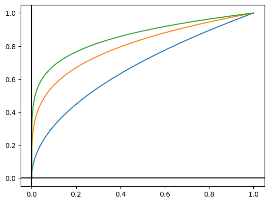

```python
x=np.linspace(0,1,1000)

plt.plot(x,x**(1/2))
plt.plot(x,x**(1/4))
plt.plot(x,x**(1/6))
plt.axhline(y = 0, color = 'k', linestyle = '-')
plt.axvline(x = 0, color = 'k', linestyle = '-')
# plt.legend(['exp','log'])
```

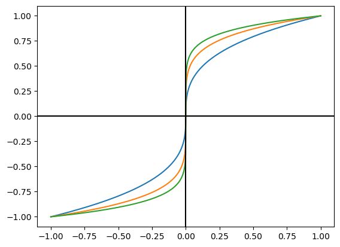

```python
x=np.linspace(-1,1,1000)
def root(x,n):
    result = []
    for val in x:
        if val > 0:
            result.append(val ** (1./n))
        elif val < 0:
            result.append(-np.abs(val) ** (1./n))
    return result

plt.plot(x,root(x,3))
plt.plot(x,root(x,5))
plt.plot(x,root(x,7))
plt.axhline(y = 0, color = 'k', linestyle = '-')
plt.axvline(x = 0, color = 'k', linestyle = '-')
# plt.legend(['exp','log'])
```

- If $a=-1$, $f(x)$ is a reciprocal function.

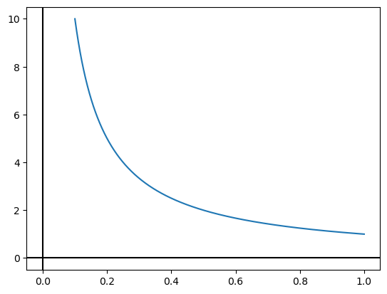

```python
x=np.linspace(0.1,1,1000)

plt.plot(x,x**(-1))
plt.axhline(y = 0, color = 'k', linestyle = '-')
plt.axvline(x = 0, color = 'k', linestyle = '-')
# plt.legend(['exp','log'])
```

## Rational Functions

\begin{equation} f(x)=\frac{P(x)}{Q(x)}, ~P(x),~Q(x)~polynomials \end{equation}

- Domain: $\{x|x\in \Re~ and~ Q(x)\ne0\}$
- $f(x)=1/x$ is also a rational function.

For example, let's plot the function:

\begin{equation} f(x)=\frac{2x^4-x^2+1}{x^2-4} \end{equation}

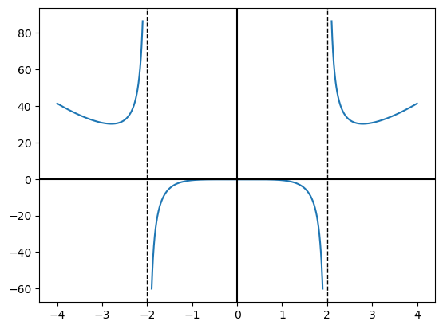

```python
x=np.linspace(-1.9,1.9,1000)
x1=np.linspace(2.1,4,1000)
x2=np.linspace(-4,-2.1,1000)

plt.plot(x,(2*x**4-x**2+1)/(x**2-4))
plt.plot(x1,(2*x1**4-x1**2+1)/(x1**2-4),color='tab:blue')
plt.plot(x2,(2*x2**4-x2**2+1)/(x2**2-4),color='tab:blue')

plt.axvline(x = 2, color = 'k', linestyle = '--',linewidth=1)
plt.axvline(x = -2, color = 'k', linestyle = '--',linewidth=1)

plt.axhline(y = 0, color = 'k', linestyle = '-')
plt.axvline(x = 0, color = 'k', linestyle = '-')
```

## Algebraic Functions

A function is called an **algebraic function** if it can be constructed using algebraic operations (such as addition, subtraction, multiplication, division, and taking roots) starting with polynomials. Any rational function is automatically an algebraic function.

Examples:

\begin{equation} f(x)=\sqrt{x^2+1} \end{equation}\begin{equation} f(x)=\frac{x^4-16x^2}{x+\sqrt{x}}+(x-2)^3\sqrt[3]{x+1} \end{equation}